# SurvivalAnalysis

Jim Matthews

03/02/2021

### R scripts to accompany the examples in the workshop

These R code chunks are largely equivalent to the SPSS syntax that was used to produce the output that is shown on the workshop slides. If you prefer to use R, you can use the following scripts as a guide. Note that the output produced by this code is not necessarily exactly the same as that produced by the SPSS syntax.

### Load packages

We will use a number of packages including “survival” and “survminer”. Refer to the list below for other packages used. If you haven’t already installed them, you will need to do this before using the library() function.

```r
library(survival)
library(survminer)
library(ggplot2)
library(ggfortify)
library(My.stepwise)
library(gt)
library(gtsummary)
```

### Load the data

The data file is WHAS500data.csv

This is found at the Wiley website here:

ftp://ftp.wiley.com/public/sci_tech_med/survival

## Kaplan Meier

Create the Kaplan-Meier survival object and include Gender as a factor.

We create a Surv() object then parse it to the survfit() function.

### We can use the plot() function to create a basic graph.

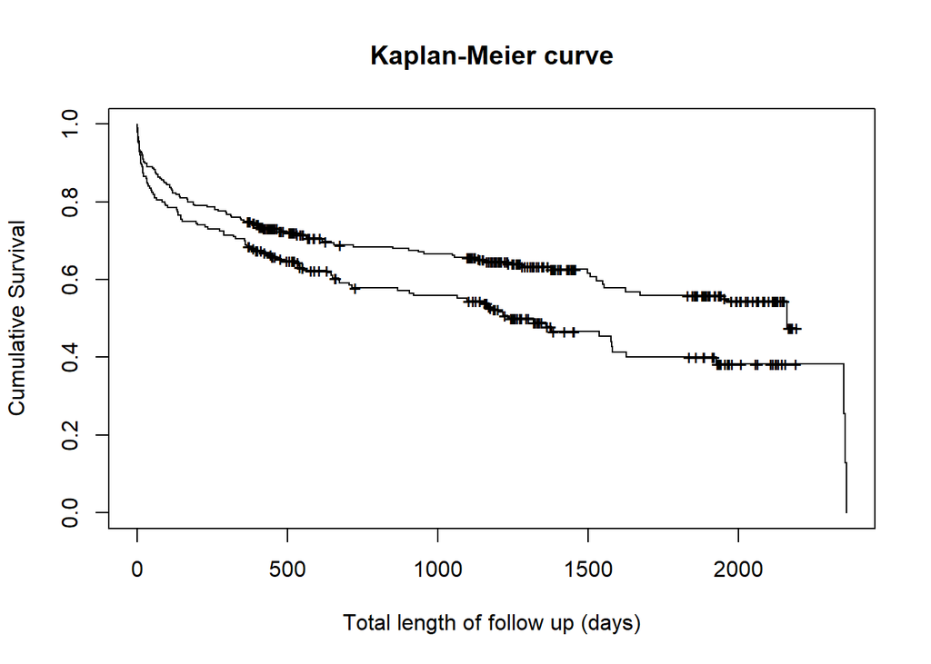

```r
kmfit <- survfit(Surv(lenfol, fstat) ~ Gender, data = whas500)
# summary(kmfit) # this is suppressed to save space.
plot(
  kmfit,
  mark = "+",
  main = "Kaplan-Meier curve",
  xlab = "Total length of follow up (days)",
  ylab = "Cumulative Survival"
)
```

### Alternative way to plot the K-M curve using ggplot2::autoplot

This includes confidence interval shading by default.

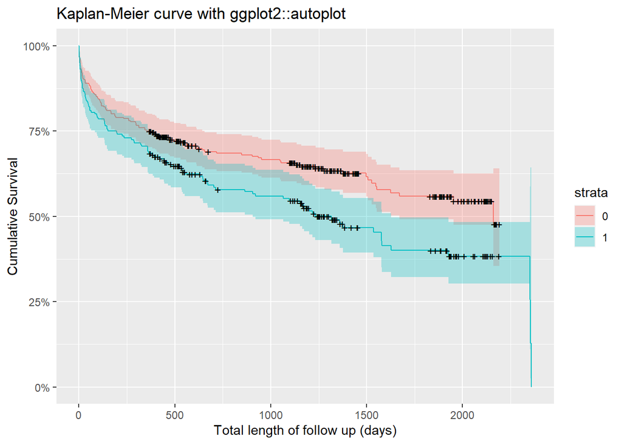

```r
ggplot2::autoplot(kmfit,
                  main = "Kaplan-Meier curve with ggplot2::autoplot",
                  xlab = "Total length of follow up (days)",
                  ylab = "Cumulative Survival"
                  )
```

### Another option is to use survminer::ggsurvplot

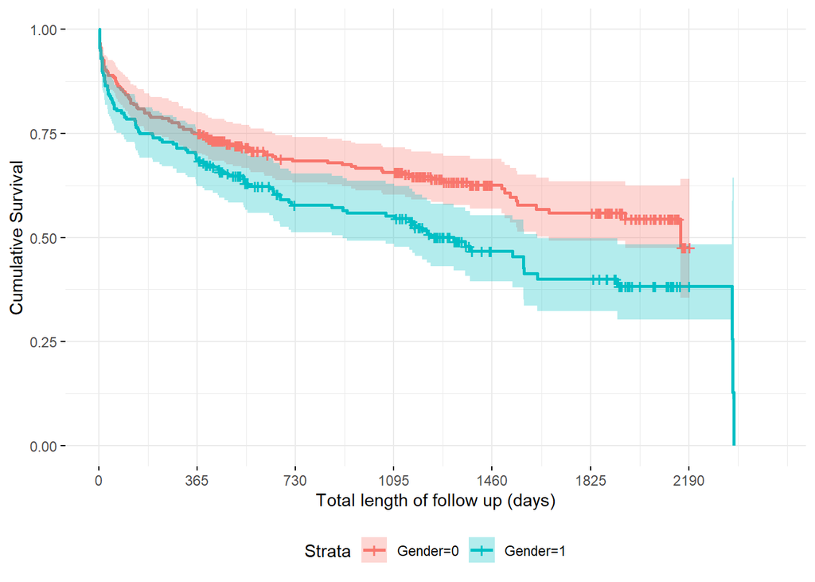

```r
ggsurvplot(
  kmfit,
  data = whas500,
  conf.int = T,
  legend = "bottom",
  main = "Kaplan-Meier curve with survminer::ggsurvplot",
  xlab = "Total length of follow up (days)",
  ylab = "Cumulative Survival",
  break.time.by = 365,
  ggtheme = theme_minimal()
)
```

## Cox Regression

Start with stepwise selection of covariates.

```r
# define list of variables to select from
var.select <-
  c(
    "Gender",
    "Age",
    "hr",
    "sysbp",
    "diabp",
    "bmi",
    "cvd",
    "afb",
    "sho",
    "chf",
    "av3",
    "miord",
    "mitype",
    "year"
  )
# Use the My.stepwise package to create the stepwise selection model
coxstep <-
  My.stepwise.coxph(
    Time = "lenfol",
    Status = "fstat",
    variable.list = var.select,
    data = whas500
  )
```

```
## # --------------------------------------------------------------------------------------------------
## # Initial Model:
## Call:
## coxph(formula = formula, data = data, method = "efron")
##
##   n= 500, number of events= 215
##
##         coef exp(coef) se(coef)     z Pr(>|z|)
## Age 0.066339  1.068589 0.006079 10.91   <2e-16 ***
## ---
## Signif. codes:  0 '***' 0.001 '**' 0.01 '*' 0.05 '.' 0.1 ' ' 1
##
##     exp(coef) exp(-coef) lower .95 upper .95
## Age     1.069     0.9358     1.056     1.081
##
## Concordance= 0.731  (se = 0.018 )
## Likelihood ratio test= 142.1  on 1 df,   p=<2e-16
## Wald test            = 119.1  on 1 df,   p=<2e-16
## Score (logrank) test = 126.6  on 1 df,   p=<2e-16
##
## # --------------------------------------------------------------------------------------------------
## ### iter num = 1, Forward Selection by LR Test: + chf
## Call:
## coxph(formula = Surv(lenfol, fstat) ~ Age + chf, data = data,
##     method = "efron")
##
##   n= 500, number of events= 215
##
##         coef exp(coef) se(coef)     z Pr(>|z|)
## Age 0.058687  1.060443 0.006097 9.626  < 2e-16 ***
## chf 0.862128  2.368195 0.142333 6.057 1.39e-09 ***
## ---
## Signif. codes:  0 '***' 0.001 '**' 0.01 '*' 0.05 '.' 0.1 ' ' 1
##
##     exp(coef) exp(-coef) lower .95 upper .95
## Age     1.060     0.9430     1.048     1.073
## chf     2.368     0.4223     1.792     3.130
##
## Concordance= 0.757  (se = 0.017 )
## Likelihood ratio test= 178.2  on 2 df,   p=<2e-16
```

[output cut: 235 more lines]

```
## hr        1.0118     0.9884    1.0060    1.0176
## diabp     0.9882     1.0120    0.9815    0.9949
## bmi       0.9500     1.0527    0.9196    0.9813
## year      1.2814     0.7804    1.0543    1.5575
## Gender    0.7330     1.3643    0.5522    0.9729
##
## Concordance= 0.787  (se = 0.015 )
## Likelihood ratio test= 228.1  on 8 df,   p=<2e-16
## Wald test            = 209.6  on 8 df,   p=<2e-16
## Score (logrank) test = 233.4  on 8 df,   p=<2e-16
##
## --------------- Variance Inflating Factor (VIF) ---------------
## Multicollinearity Problem: Variance Inflating Factor (VIF) is bigger than 10 (Continuous Variable) or is bigger than 2.5 (Categorical Variable)
##      Age      chf      sho       hr    diabp      bmi     year   Gender
## 1.137430 1.054373 1.013467 1.085882 1.060169 1.110415 1.017812 1.083232
```

## Collett method for variable selection

These will use the survival::coxph() function

Model 1: null model

```r
cox01 <- coxph(Surv(lenfol, fstat) ~ 1, data = whas500)
AIC01 <- extractAIC(cox01)
```

Model 2: Age

```r
cox02 <- coxph(Surv(lenfol, fstat) ~ Age, data = whas500)
AIC02 <- extractAIC(cox02)
```

Model 3: Gender

```r
cox03 <- coxph(Surv(lenfol, fstat) ~ Gender, data = whas500)
AIC03 <-extractAIC(cox03)
```

Model 4: BMI

```r
cox04 <- coxph(Surv(lenfol, fstat) ~ bmi, data = whas500)
AIC04 <- extractAIC(cox04)
```

Model 5: Heart Rate

```r
cox05 <- coxph(Surv(lenfol, fstat) ~ hr, data = whas500)
AIC05 <- extractAIC(cox05)
```

Model 6: Age + Gender + BMI

```r
cox06 <- coxph(Surv(lenfol, fstat) ~ Age + Gender + bmi, data = whas500)
AIC06 <- extractAIC(cox06)
```

Model 7: Age + Gender + HR

```r
cox07 <- coxph(Surv(lenfol, fstat) ~ Age + Gender + hr, data = whas500)
AIC07 <- extractAIC(cox07)
```

Model 8: Age + BMI + HR

```r
cox08 <- coxph(Surv(lenfol, fstat) ~ Age + bmi + hr, data = whas500)
AIC08 <- extractAIC(cox08)
```

Model 9: Gender + BMI + HR

```r
cox09 <- coxph(Surv(lenfol, fstat) ~ Gender + bmi + hr, data = whas500)
AIC09 <- extractAIC(cox09)
```

Model 10: Age+Gender+BMI+HR

```r
cox10 <- coxph(Surv(lenfol, fstat) ~ Age + Gender + bmi + hr, data = whas500)
AIC10 <- extractAIC(cox10)
```

## Linearity of continuous predictors

Create a variable for BMI categories

```r
bmi.cat <- cut(whas500$bmi, breaks = c(0, 18.5, 25, 30, 9999), labels = c("underweight", "normal weight", "overweight", "obese"), right = F)
whas500$bmi.cat <- bmi.cat
```

Have a look at the Kaplan-Meier curves with BMI categories

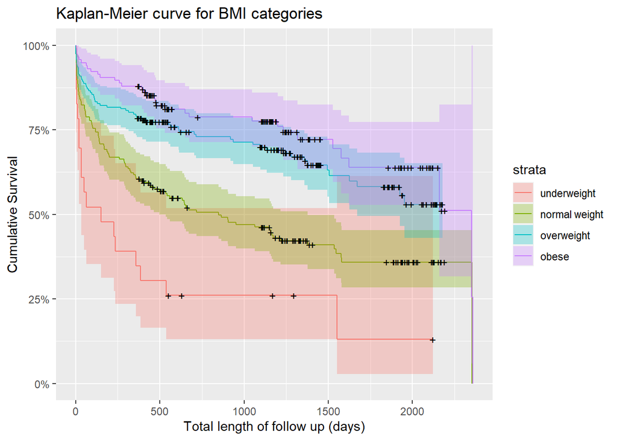

```r
km.bmi.cat <- survfit(Surv(lenfol, fstat) ~ bmi.cat, data = whas500)
ggplot2::autoplot(km.bmi.cat,
                  main = "Kaplan-Meier curve for BMI categories",
                  xlab = "Total length of follow up (days)",
                  ylab = "Cumulative Survival"
                  )
```

### Model 11: Age + Gender + BMI(cat) + HR

Create models including the BMI category variable

```r
cox11 <- coxph(Surv(lenfol, fstat) ~ Age + Gender + bmi.cat + hr, data = whas500)
AIC11 <- extractAIC(cox11)
cox11.fit <- survfit(cox11)
gtsummary::tbl_regression(cox11, exponentiate = T)
```

| **Characteristic** | **HR**<sup>1</sup> | **95% CI**<sup>1</sup> | **p-value** |
| --- | --- | --- | --- |
| Age | 1.06 | 1.05, 1.08 | <0.001 |
| Gender | 0.82 | 0.62, 1.08 | 0.2 |
| bmi.cat |  |  |  |
| underweight | — | — |  |
| normal weight | 0.78 | 0.47, 1.30 | 0.3 |
| overweight | 0.48 | 0.28, 0.83 | 0.008 |
| obese | 0.54 | 0.29, 1.00 | 0.050 |
| hr | 1.01 | 1.01, 1.02 | <0.001 |

<sup>*1*</sup> HR = Hazard Ratio, CI = Confidence Interval

### Plot the Cox model 11 survival curves for the BMI categories

Cox survival curves using survminer::ggadjustedcurves

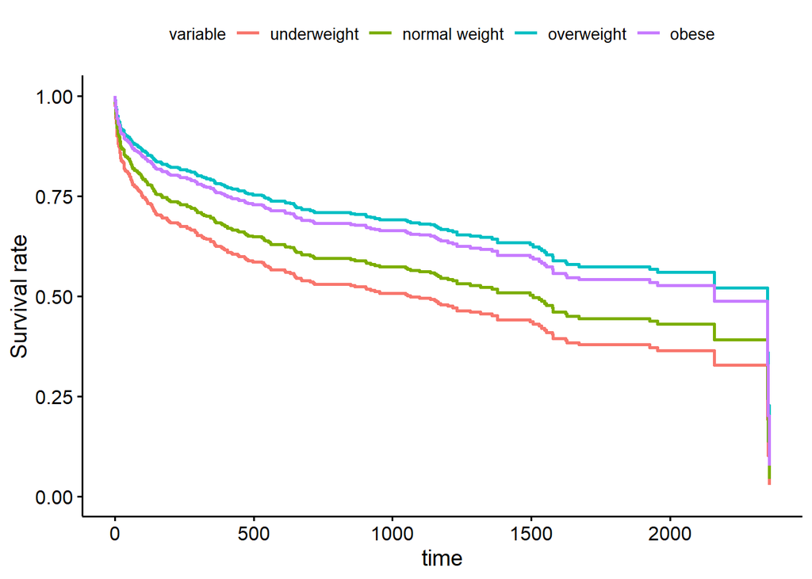

```r
ggadjustedcurves(cox11, data = whas500, variable = "bmi.cat")
```

## Schoenfeld Residuals

Have a look at the plot for the Gender variable (Model 3) using survminer::ggcoxdiagnostics

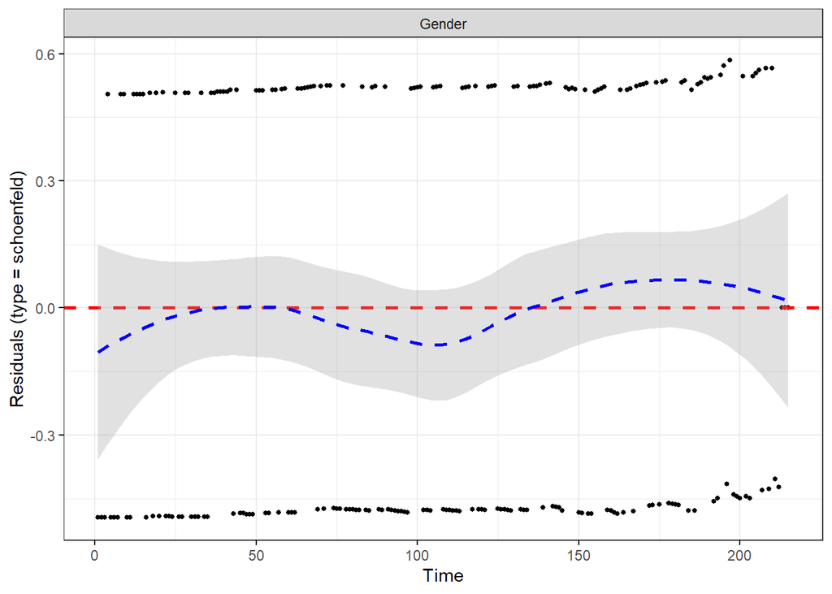

```r
ggcoxdiagnostics(cox03, type = "schoenfeld", ox.scale = "time")
```

The residual plot looks OK. The blue dashed line does not significantly depart from the null assumption of the red dashed line.

## Test of proportional hazards assumption

### Model 3 - Gender

Note: This is not available through the SPSS syntax.

```r
cox03.test <- cox.zph(cox03)
cox03.test
```

```
##        chisq df    p
## Gender 0.755  1 0.38
## GLOBAL 0.755  1 0.38
```

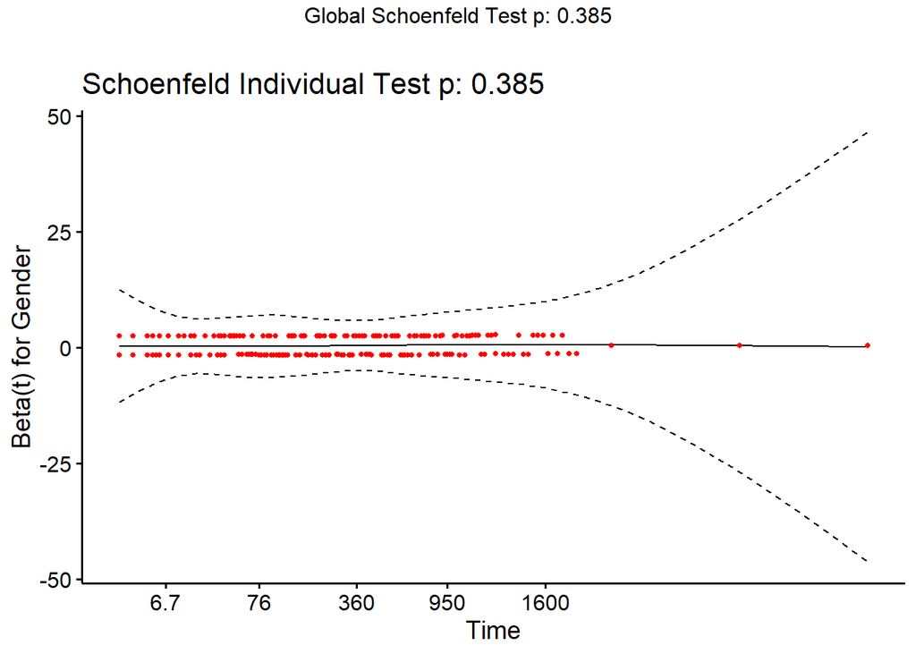

```r
ggcoxzph(cox03.test)
```

The plot and the chi-sq statistic indicate no concern regarding the assumption of proportional hazards for the Gender variable.

see from slide 72

### Goodness of fit

Refer to the pseudo R sq from coxph()

Looking at the output below, it does not seem to be there. Need to check.

```r
summary(cox11)
```

```
## Call:
## coxph(formula = Surv(lenfol, fstat) ~ Age + Gender + bmi.cat +
##     hr, data = whas500)
##
##   n= 500, number of events= 215
##
##                           coef exp(coef)  se(coef)      z Pr(>|z|)
## Age                   0.060908  1.062801  0.006523  9.337  < 2e-16 ***
## Gender               -0.201298  0.817669  0.143506 -1.403  0.16070
## bmi.catnormal weight -0.249975  0.778820  0.260892 -0.958  0.33798
## bmi.catoverweight    -0.737154  0.478474  0.279289 -2.639  0.00831 **
## bmi.catobese         -0.613867  0.541254  0.313726 -1.957  0.05038 .
## hr                    0.012671  1.012751  0.002777  4.563 5.04e-06 ***
## ---
## Signif. codes:  0 '***' 0.001 '**' 0.01 '*' 0.05 '.' 0.1 ' ' 1
##
##                      exp(coef) exp(-coef) lower .95 upper .95
## Age                     1.0628     0.9409    1.0493    1.0765
## Gender                  0.8177     1.2230    0.6172    1.0833
## bmi.catnormal weight    0.7788     1.2840    0.4671    1.2987
## bmi.catoverweight       0.4785     2.0900    0.2768    0.8272
## bmi.catobese            0.5413     1.8476    0.2927    1.0010
## hr                      1.0128     0.9874    1.0073    1.0183
##
## Concordance= 0.753  (se = 0.017 )
## Likelihood ratio test= 173.2  on 6 df,   p=<2e-16
## Wald test            = 151.3  on 6 df,   p=<2e-16
## Score (logrank) test = 168.4  on 6 df,   p=<2e-16
```

### End of Survival workshop examples